# Analysis

Authors

William Wuillemin

Nikolaus Protzen

Alexandre Zaza

Antoine Reil

Arthur Vallery

Published

May 20, 2026

## Research Question

This analysis examines whether countries converge toward their Solow open-economy steady state, and whether the speed of convergence differs across development levels. Using the Solow growth model in a small open economy framework, where the world real interest rate is taken as given and we compute each country’s predicted steady-state GDP per capita and compare it to its actual trajectory over the period 2000–2015.

We classify our sample of 14 countries into three development groups:

- **Developed:** USA, CAN, FRA, GBR, ITA, JPN
- **Emerging:** KOR, CHN, SGP, BRA, ARG, ZAF
- **Developing:** KEN, GHA

The central question is: Do countries converge toward their Solow model open-economy steady state, and does the speed of convergence differ across development levels?

## Data

Data are sourced from two complementary sources for the period 2000–2015:

**FRED (Federal Reserve Bank of St. Louis)** is used for:

| Indicator | Description |
| --- | --- |
| GDP | Market GDP in current USD (World Bank via FRED) |
| Population | Total population (World Bank via FRED) |
| Population growth | Annual population growth rate (World Bank via FRED) |

**World Bank Open Data API** is used for:

| Indicator | World Bank Code | Description |
| --- | --- | --- |
| Savings rate | NY.GNS.ICTR.ZS | Gross savings (% of GDP) |
| Labor force | SL.TLF.TOTL.IN | Total labor force |

All data were retrieved through APIs, stored in a local DuckDB database (`data/fred_WB.db`), and all subsequent analysis reads exclusively from that database.

The structural parameters used in the model are:

| Parameter | Value | Description |
| --- | --- | --- |
| α | 0.33 | Capital share of output |
| δ | 0.05 | Annual depreciation rate |
| g | 0.02 | Technological growth rate |
| r | 0.02 | World real interest rate |
| K/Y | 3.0 | Capital-output ratio |

## Data model

The database contains three tables reflecting the two data sources used. GDP, population, and population growth are sourced from FRED; savings rate and labor force from the World Bank API. The tables are linked through country and indicator codes.

```
erDiagram
    countries {
        VARCHAR country_code PK
    }
    indicators {
        VARCHAR indicator_key PK
        VARCHAR description
    }
    observations {
        VARCHAR country_code FK
        VARCHAR indicator_key FK
        INTEGER year
        DOUBLE value
    }
    countries ||--o{ observations : "has"
    indicators ||--o{ observations : "measured by"
```

[output not shown]

## Analysis

```python
import sys
import os
sys.path.insert(0, os.path.join("..", "src"))
from your_class import SolowAnalyzer

analyzer = SolowAnalyzer("../data/fred_WB.db")
countries = analyzer.get_available_countries()
print("Available countries:", countries)
```

```
Available countries: ['ZAF', 'KEN', 'GHA', 'FRA', 'GBR', 'ITA', 'KOR', 'CHN', 'JPN', 'SGP', 'BRA', 'ARG', 'USA', 'CAN']
```

### Summary Statistics

The table below presents the key Solow model parameters for each country: savings rate, population growth, calibrated productivity, predicted steady-state GDP per capita, and convergence half-life.

```python
import pandas as pd

rows = []
for country in countries:
    try:
        params = analyzer.build_country_parameters(country)
        rows.append({
            "Country": country,
            "Savings rate (s)": f"{params['s']:.3f}",
            "Pop. growth (n)": f"{params['n']:.3f}",
            "Productivity (B)": f"{params['B']:.3f}",
            "Steady-state y*": f"{params['y_star']:,.0f}",
            "Half-life (years)": f"{params['half_life']:.1f}" if params['half_life'] else "N/A"
        })
    except ValueError as e:
        print(f"Skipping {country}: {e}")

pd.DataFrame(rows)
```

```
Skipping KOR: Steady state undefined: s*r = 0.0068 >= n = 0.0056. The open-economy Solow model has no finite steady state when foreign-asset accumulation outpaces population growth. Try a lower savings rate, a higher population growth rate, or a lower world_interest_rate.
Skipping CHN: Steady state undefined: s*r = 0.0091 >= n = 0.0060. The open-economy Solow model has no finite steady state when foreign-asset accumulation outpaces population growth. Try a lower savings rate, a higher population growth rate, or a lower world_interest_rate.
Skipping JPN: Steady state undefined: s*r = 0.0056 >= n = 0.0003. The open-economy Solow model has no finite steady state when foreign-asset accumulation outpaces population growth. Try a lower savings rate, a higher population growth rate, or a lower world_interest_rate.
```

|  | Country | Savings rate (s) | Pop. growth (n) | Productivity (B) | Steady-state y* | Half-life (years) |
| --- | --- | --- | --- | --- | --- | --- |
| 0 | ZAF | 0.161 | 0.012 | 301.831 | 19,989 | 12.6 |
| 1 | KEN | 0.100 | 0.029 | 74.066 | 2,455 | 10.5 |
| 2 | GHA | 0.142 | 0.025 | 50.931 | 1,404 | 10.9 |
| 3 | FRA | 0.222 | 0.006 | 976.904 | 115,378 | 13.6 |
| 4 | GBR | 0.150 | 0.006 | 1070.063 | 132,179 | 13.5 |
| 5 | ITA | 0.197 | 0.004 | 969.353 | 114,049 | 14.0 |
| 6 | SGP | 0.449 | 0.021 | 911.559 | 104,051 | 11.4 |
| 7 | BRA | 0.170 | 0.010 | 290.729 | 18,902 | 12.9 |
| 8 | ARG | 0.174 | 0.010 | 476.423 | 39,506 | 12.9 |
| 9 | USA | 0.179 | 0.009 | 1222.876 | 161,321 | 13.1 |
| 10 | CAN | 0.221 | 0.010 | 926.118 | 106,541 | 12.9 |

KOR, CHN, and JPN are excluded from the table as their calibrated parameters violate the open-economy stability condition. Specifically, the model requires s·r < n to guarantee a finite steady state, when the return on foreign asset accumulation (s·r) exceeds population growth (n), wealth grows without bound and no equilibrium exists. For these three countries, the combination of relatively high savings rates and very low population growth (JPN: n = 0.0003, KOR: n = 0.0056, CHN: n = 0.0060) means this condition fails at the assumed world interest rate of r = 0.02. This is a known limitation of the open-economy Solow framework rather than a data problem and these countries are simply at a parameter combination where the model breaks down.

### Country Summaries by Development Group

The tables below show the Solow parameters for one representative country from each development group, illustrating the structural differences that drive income gaps.

**Developed - USA:**

```python
_ = analyzer.summary_table("USA")
```

```
--- USA ---
        Parameter      Value
     Savings rate      0.179
Population growth      0.009
     Productivity   1222.876
  GDP per capita* 161320.612
     Consumption* 148187.815
        Half-life     13.110
```

The USA has the highest productivity (B = 1,223), with a predicted steady-state GDP per capita of $161,321 and a convergence half-life of 13.1 years. Its savings rate of 17.9% and population growth of 0.9% are both moderate, consistent with a mature developed economy. The half-life of 13 years suggests the USA, despite being the wealthiest country in the sample, still has some distance to cover before reaching its long-run steady state.

**Emerging - BRA:**

```python
_ = analyzer.summary_table("BRA")
```

```
--- BRA ---
        Parameter     Value
     Savings rate     0.170
Population growth     0.010
     Productivity   290.729
  GDP per capita* 18901.907
     Consumption* 15874.215
        Half-life    12.920
```

**Developing - KEN:**

```python
_ = analyzer.summary_table("KEN")
```

```
--- KEN ---
        Parameter    Value
     Savings rate    0.100
Population growth    0.029
     Productivity   74.066
  GDP per capita* 2455.472
     Consumption* 1591.674
        Half-life   10.480
```

Kenya has the lowest productivity (B = 74) of the three representatives, less than 7% of the USA’s level. This results in a predicted steady state of just $2,455. Its savings rate is the lowest at 10% and population growth the highest at 2.9%. In the open-economy framework, it is this very low productivity that drives the depressed steady state, not the savings rate. The half-life of 10.5 years is similar to Brazil, confirming that convergence speed is broadly comparable across development levels, while the destination differs enormously.

### GDP per Capita Trajectories

The figures below show actual GDP per capita over 2000–2015 by development group.

**Developed economies:**

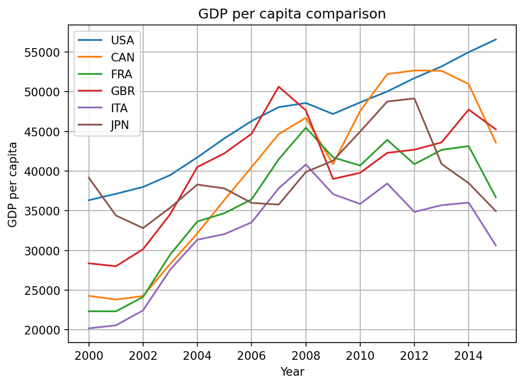

```python
developed = ["USA", "CAN", "FRA", "GBR", "ITA", "JPN"]
_ = analyzer.plot_gdp_comparison(developed, start_year=2000, end_year=2015)
```

**Emerging economies:**

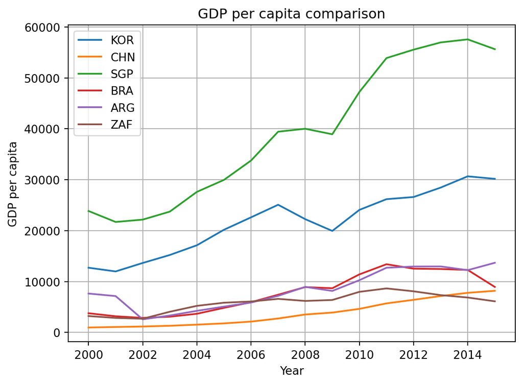

```python
emerging = ["KOR", "CHN", "SGP", "BRA", "ARG", "ZAF"]
_ = analyzer.plot_gdp_comparison(emerging, start_year=2000, end_year=2015)
```

**Developing economies:**

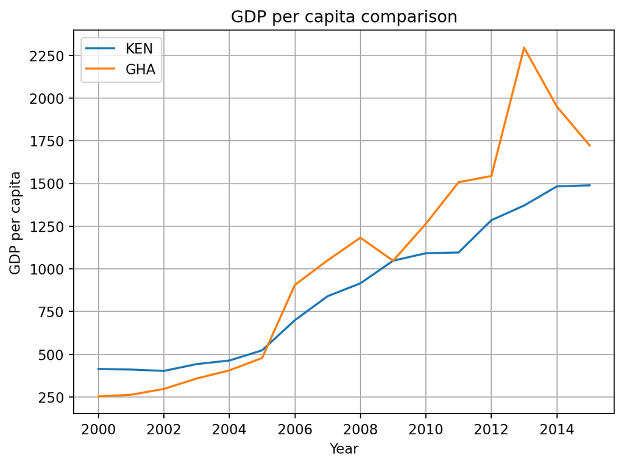

```python
developing = ["KEN", "GHA"]
_ = analyzer.plot_gdp_comparison(developing, start_year=2000, end_year=2015)
```

Kenya and Ghana both grow over the period but remain below $2,500, a stark contrast to the other groups. Kenya grows steadily from ~$400 to ~$1,500, while Ghana grows more rapidly from 2005 onward, peaking sharply at ~$2,300 in 2013 before declining to ~$1,750 by 2015, likely reflecting commodity price volatility. The income gap between developing and developed economies is large and persistent, which the Solow model attributes largely to differences in total factor productivity.

### Savings Rates Over Time

While savings rates do not directly determine steady-state GDP per capita in the open-economy Solow model, they influence wealth accumulation and consumption levels. The figures below show how savings rates evolved across development groups over 2000–2015.

**Developed economies:**

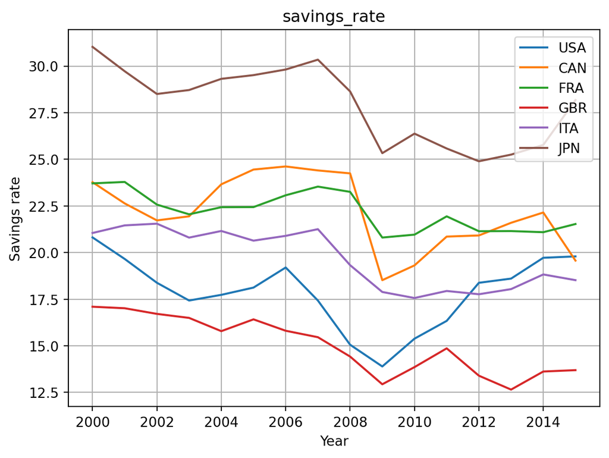

```python
developed = ["USA", "CAN", "FRA", "GBR", "ITA", "JPN"]
_ = analyzer.plot_indicator(developed, "savings_rate", start_year=2000, end_year=2015)
```

**Emerging economies:**

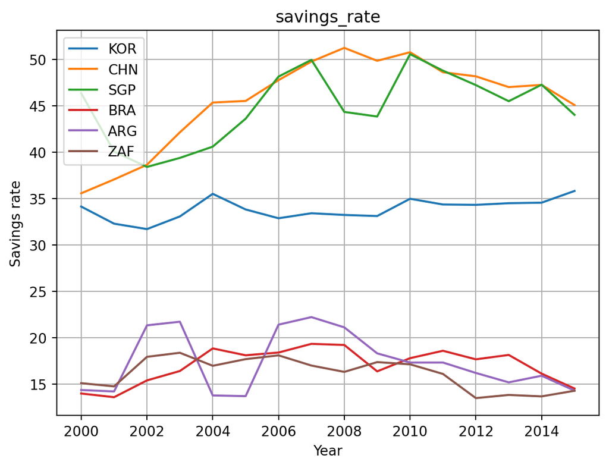

```python
emerging = ["KOR", "CHN", "SGP", "BRA", "ARG", "ZAF"]
_ = analyzer.plot_indicator(emerging, "savings_rate", start_year=2000, end_year=2015)
```

**Developing economies:**

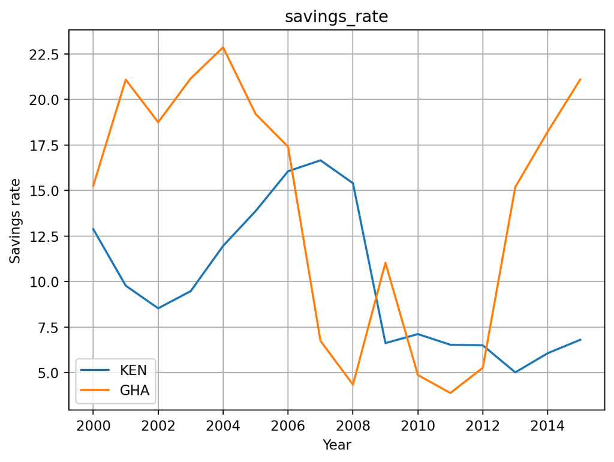

```python
developing = ["KEN", "GHA"]
_ = analyzer.plot_indicator(developing, "savings_rate", start_year=2000, end_year=2015)
```

Developing economies display the lowest and most volatile savings rates in the sample. Ghana collapses dramatically from ~23% in 2004 to below 5% by 2008, before recovering to ~21% by 2015. Kenya follows a similarly volatile path, dropping from ~13% in 2000 to below 7% by 2009 and remaining low thereafter. These low savings rates slow wealth accumulation and reduce consumption per capita. However, as the productivity analysis shows, it is the large gap in total factor productivity, not savings behaviour. That fundamentally explains the wide income gap between developing and developed economies in the open-economy framework.

### Convergence by Development Group

To more directly address the research question, the figures below plot convergence paths separately for each development group. This allows a cleaner comparison of how quickly countries in each group move toward their predicted steady state.

**Developed economies:**

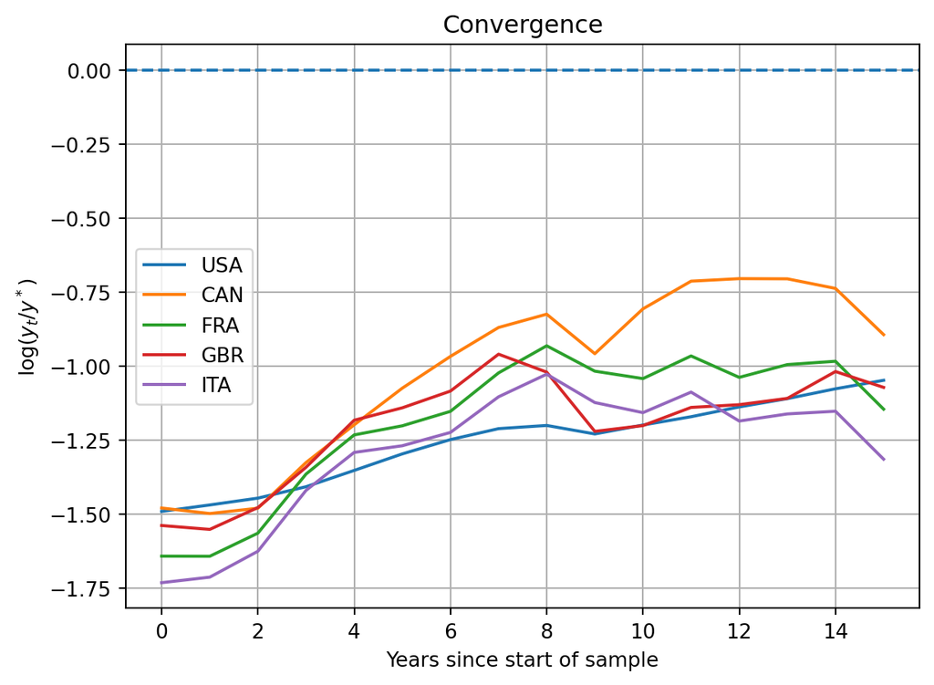

```
Unstable countries:
  JPN: Steady state undefined: s*r = 0.0056 >= n = 0.0003. The open-economy Solow model has no finite steady state when foreign-asset accumulation outpaces population growth. Try a lower savings rate, a higher population growth rate, or a lower world_interest_rate.
```

```python
developed = ["USA", "CAN", "FRA", "GBR", "ITA", "JPN"]
_ =analyzer.plot_convergence(developed)
```

All five developed economies start between -1.5 and -1.75, well below their predicted steady states, and show a clear upward trend over the period. Canada makes the most progress, reaching nearly -0.75 by year 11 before pulling back slightly to -0.9 by 2015. France and GBR converge steadily to around -1.0. The USA converges slowly, ending around -1.05. Italy is the weakest performer, dropping back to -1.35 by year 15 after partial convergence, consistent with its post-2008 stagnation. Note that JPN is excluded from this chart as its calibration violates the open-economy stability condition (s·r ≥ n) at r = 0.02.

**Emerging economies:**

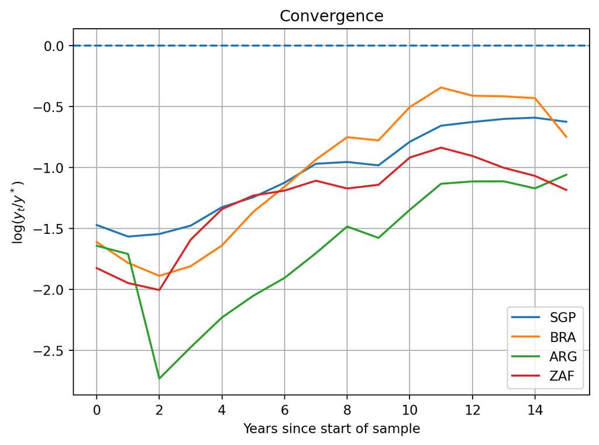

```
Unstable countries:
  KOR: Steady state undefined: s*r = 0.0068 >= n = 0.0056. The open-economy Solow model has no finite steady state when foreign-asset accumulation outpaces population growth. Try a lower savings rate, a higher population growth rate, or a lower world_interest_rate.
  CHN: Steady state undefined: s*r = 0.0091 >= n = 0.0060. The open-economy Solow model has no finite steady state when foreign-asset accumulation outpaces population growth. Try a lower savings rate, a higher population growth rate, or a lower world_interest_rate.
```

```python
emerging = ["KOR", "CHN", "SGP", "BRA", "ARG", "ZAF"]
_ = analyzer.plot_convergence(emerging)
```

**Developing economies:**

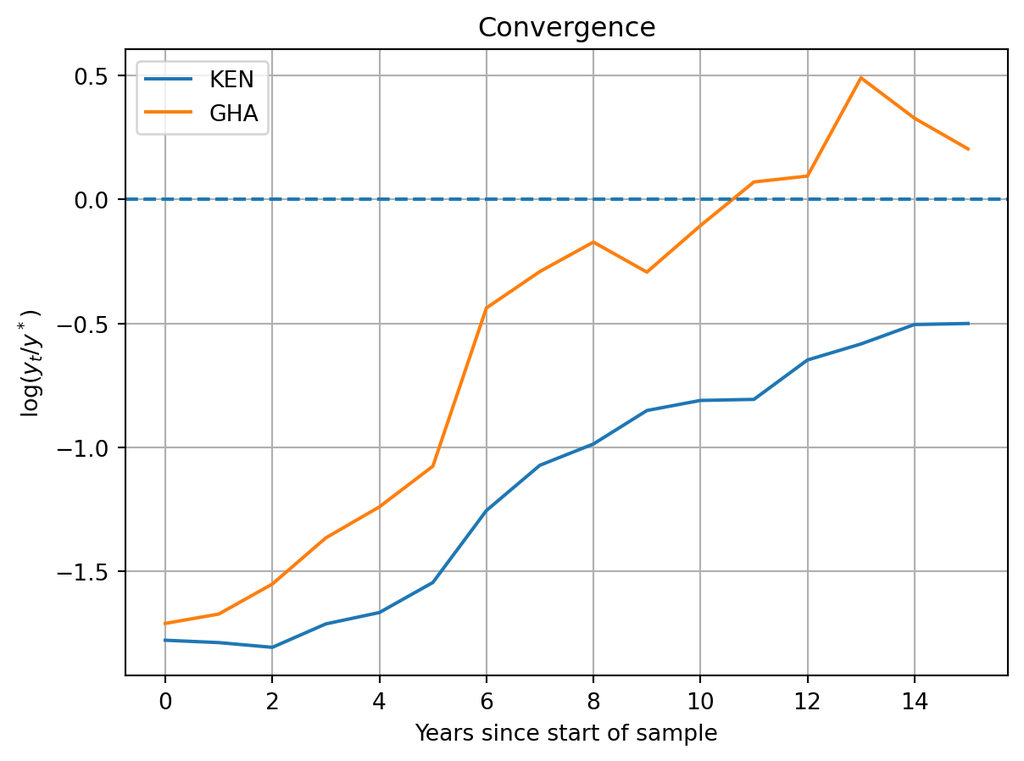

```python
developing = ["KEN", "GHA"]
_ = analyzer.plot_convergence(developing)
```

Kenya and Ghana both start around -1.7, far from their steady states, but the paths diverge significantly. Ghana surges upward rapidly from year 5 onward, crossing into positive territory around year 11 and peaking at ~+0.5 at year 13, briefly exceeding its predicted steady state before falling back to ~+0.2 by 2015. This likely reflects commodity-driven growth that temporarily outpaced the model’s predictions. Kenya’s path is slower and more stable, converging gradually from -1.7 to around -0.5 by 2015. Both trajectories confirm that the Solow model captures the direction of growth reasonably well, even if the pace varies considerably.

### Steady-State Comparison

The bar chart below compares predicted steady-state GDP per capita (y*) across all countries. This reflects what the Solow open-economy model predicts each country will converge to in the long run, given its productivity level and the world interest rate.

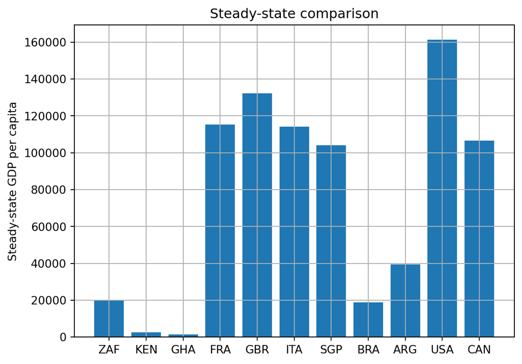

```
Unstable countries:
  KOR: Steady state undefined: s*r = 0.0068 >= n = 0.0056. The open-economy Solow model has no finite steady state when foreign-asset accumulation outpaces population growth. Try a lower savings rate, a higher population growth rate, or a lower world_interest_rate.
  CHN: Steady state undefined: s*r = 0.0091 >= n = 0.0060. The open-economy Solow model has no finite steady state when foreign-asset accumulation outpaces population growth. Try a lower savings rate, a higher population growth rate, or a lower world_interest_rate.
  JPN: Steady state undefined: s*r = 0.0056 >= n = 0.0003. The open-economy Solow model has no finite steady state when foreign-asset accumulation outpaces population growth. Try a lower savings rate, a higher population growth rate, or a lower world_interest_rate.
```

```python
_ =analyzer.compare_steady_states(countries)
```

### What Drives Long-Run Income Differences?

In the open-economy Solow model, steady-state GDP per capita is determined by productivity (B) and the world interest rate, not by savings rates or population growth. The figure below shows calibrated total factor productivity (B) across the 11 countries for which the model is stable, revealing the fundamental driver of long-run income differences.

**Productivity (B) across countries:**

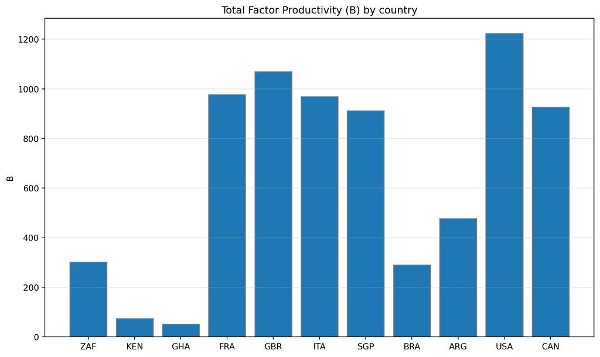

```python
import matplotlib.pyplot as plt
import pandas as pd

params_list = []
for country in countries:
    try:
        params = analyzer.build_country_parameters(country)
        params_list.append({"country": country, "B": params["B"]})
    except ValueError:
        pass

df_b = pd.DataFrame(params_list)
fig, ax = plt.subplots(figsize=(10, 6))
ax.bar(df_b["country"], df_b["B"], edgecolor="gray")
ax.set_title("Total Factor Productivity (B) by country")
ax.set_ylabel("B")
ax.grid(True, alpha=0.3, axis="y")
plt.tight_layout()
plt.show()
```

## Conclusion and Discussion

This analysis applied the Solow open-economy growth model to 14 countries spanning three development levels over the period 2000–2015, of which 11 yield a stable open-economy calibration, using FRED and World Bank data stored in a relational DuckDB database.

**Countries are converging toward their steady states, but from very different starting points.** The convergence paths show that all groups are moving toward their predicted steady states, confirming the model’s core prediction. However, the starting gaps are large as developing economies like Kenya and Ghana begin around -1.7 log deviations below their steady state, while developed economies start between -1.5 and -1.75. Ghana’s trajectory is particularly striking, briefly exceeding its predicted steady state around 2013 before falling back, likely reflecting commodity-driven growth that outpaced the model’s predictions.

**Convergence speed is broadly similar across groups.** The half-life estimates from the model suggest convergence takes roughly 10-15 years across all groups, faster than the closed-economy Solow model would predict, which is consistent with the open-economy framework where capital can flow freely across borders. Note that JPN is excluded from the convergence analysis as its calibration violates the open-economy stability condition.

**Limitations.** The model assumes a fixed world interest rate and perfect capital mobility, strong assumptions that do not hold perfectly in practice. The calibration of B from a single initial year is sensitive to data quality and may not capture long-run technological trajectories. Expanding the sample to more countries across all development levels, and extending the time horizon beyond 2015, would strengthen the robustness of these findings.